# **Soil Spectroscopy**

**Author:** Sadia Mitu  
**Published:** October 16, 2025

## **1 Introduction**

This hands-on guide demonstrates how to preprocess, explore, and model **Mid-Infrared (MIR) soil spectra** using Python.  
We replicate the workflow commonly used in soil spectral modeling:

- signal preprocessing (SNV + Savitzky–Golay),
- dimensionality reduction (PCA + outlier detection),
- chemometric regression (PLSR), and
- deep-learning regression (MLP).

### **1.1 Fitness-for-Purpose**

Accurate soil spectroscopy models require data processing tailored to the analytical objective — in this case, predicting key soil properties from MIR spectra.

#### **1.1.2 Example 2: Soil Classification Using the KSSL MIR Soil Spectral Library**

The USDA KSSL MIR library provides thousands of well-curated soil spectra used to train machine-learning models that estimate pH, organic carbon, and texture fractions.  
Here we reproduce a scaled-down workflow using your dataset `MIR_spectra.csv`.

### **1.2 Good Predictions Flow from Good Data**

Spectral measurements often contain scattering and baseline effects. Preprocessing removes these systematic errors to emphasize chemical absorption features.

### **1.3 Good Practices for Model Building**

- Always visualize raw spectra before transformation.
- Use standardized preprocessing across models.
- Split data randomly but reproducibly.
- Report R², RMSE, and Bias.

## **2 Processing**

### **2.1 Importing Spectra**

```python
import pandas as pd
df = pd.read_csv("MIR_spectra.csv")
```

**2.2 Tabular Operations**

```python
def is_wl(c):
    try: float(c); return True
    except: return False

wave_cols = [c for c in df.columns if is_wl(c)]
```

**2.3 Visualization — Raw Spectra**

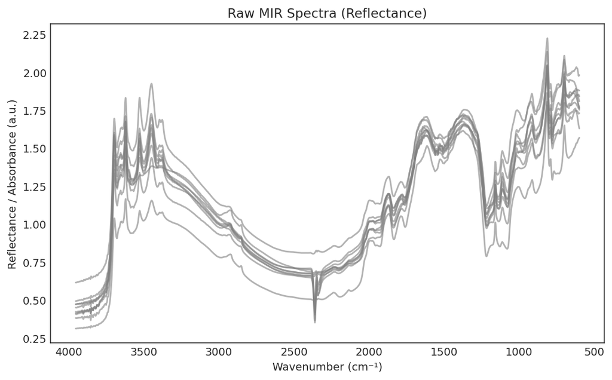

```python
import matplotlib.pyplot as plt
import seaborn as sns
sns.set_style("white")

X_raw = df[wave_cols].copy()
wavelengths = pd.to_numeric(X_raw.columns)

plt.figure(figsize=(8,5))
for i in range(10):
    plt.plot(wavelengths, X_raw.iloc[i,:], color='gray', alpha=0.6)
plt.gca().invert_xaxis()
plt.title("Raw MIR Spectra (Reflectance)")
plt.xlabel("Wavenumber (cm⁻¹)")
plt.ylabel("Reflectance / Absorbance (a.u.)")
plt.tight_layout()
plt.show()
```

**2.4 Preprocessing**

Apply Standard Normal Variate (SNV) and the Savitzky–Golay derivative.

```python
from scipy.signal import savgol_filter
import numpy as np

def snv_df(Xdf):
    mu = Xdf.mean(axis=1)
    sd = Xdf.std(axis=1).replace(0, np.finfo(float).eps)
    return Xdf.sub(mu, axis=0).div(sd, axis=0)

def sg_derivative(X, window=11, poly=2, deriv=1):
    return np.apply_along_axis(lambda r: savgol_filter(r, window, poly, deriv), 1, X)

X_snv = snv_df(X_raw)
X_sg = sg_derivative(X_snv.values, window=11, poly=2, deriv=1)
X_pre = pd.DataFrame(X_sg, columns=wavelengths)
```

**2.5 Visualization — After Preprocessing**

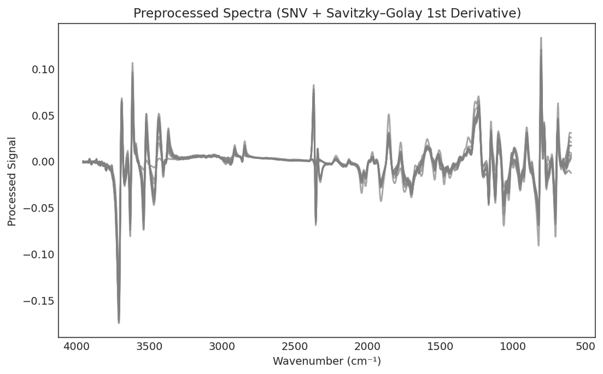

```python
plt.figure(figsize=(8,5))
for i in range(10):
    plt.plot(wavelengths, X_pre.iloc[i,:], color='grey', alpha=0.7)
plt.gca().invert_xaxis()
plt.title("Preprocessed Spectra (SNV + Savitzky–Golay 1st Derivative)")
plt.xlabel("Wavenumber (cm⁻¹)")
plt.ylabel("Processed Signal")
plt.tight_layout()
plt.show()
```

**3 Machine Learning**